# Examen Módulo 1

Rodrigo Gutiérrez Del Bosque - A01382212

2023-05-12

## 0.1 Preguntas

*Describir al menos 3-5 diferencias entre análisis exploratorio de datos (EDA) y análisis exploratorio espacial de datos (ESDA).*

- La principal diferencia será que claramente en el EDA se hace un análisis de variables NO espaciales. Esto incluye estadisticas descriptivas de variables numéricas, la visualización de estas, ver la distribución, etc. Por el contrario, con el ESDA incluimos también variables espaciales que nos indican cómo se distribuyen nuestras variables dependiendo de dónde se localizan.
- Mientras que en el EDA tomamos en cuenta la correlación que existen entre las variables numéricas, en el ESDA tomamos en cuenta la autocorrelación espacial, la cual nos indica si las variables y sus valores se relacionan con su ubicación. Esto puede ser local y/o global, algo que no se incluye en el EDA.
- Mientras que en el EDA tendremos gráficas como boxplots, diagramas de dispersión, gráficas de barras, etc., en el ESDA nuestros principales gráficas serán mapas. En estos mapas podemos ver las autocorrelaciones, los valores por ubicación, los p values de predicciones, entre otros aspectos.

*Describir al menos 3-5 diferencias entre la estimación de modelo de regresión no espacial, espacial global, y espacial local*

- La principal diferencia existe entre los modelos no espaciales y los espaciales (ya sean globales o locales) en cuanto a que en el primero no se toma en cuenta si el valor de las variables cambia dependiendo del lugar en específico o de sus vecinos. En cambio, los modelos espaciales incluyen esta variable.
- Una diferencia importante entre los modelos espaciales locales y los globales es que en modelos locales como el GWR se hace una regresión para cada uno de los puntos estudiados, dándole distintos pesos a los otros puntos dependiendo de su cercanía. Por el contrario, en el global se usa la autocorrelación espacial global y no se hacen regresiones para cada uno de los puntos.
- En una regresión global se hace únicamente una regresión, por lo que las variables independientes solo tendrán un solo valor o coeficiente. Por el contrario, la regresión local hace una para cada lugar, por lo que existen coeficientes predecidos para las variables independientes en cada lugar. Esto es debido a que el primero toma en cuenta que no varía mucho la relación en toda el área entre dependiente e independientes.

*Describir al menos 3-5 diferencias entre GWR y GRF*

- EN GWR se realiza un modelo de regresión para cada área (por ejemplo, en el de COVID para cada municipio). Por el contrario, con el GRF estamos haciendo un modelo más global que no realiza regresiones o regresiones para cada lugar local en específico.
- En GWR se toma en cuenta qué tan cercano es un punto o lugar de otro para asignarle un peso en la regresión. En GRF se toma un aspecto más global, ya que su propósito no es el identificar variables locales, si no que es el observar la autocorrelación global para predecir.
- El GRF se convirtió en una manera de combinar lo que es un modelo de Machine Learning con el análisis geo-espacial, mientras que el GWR es un modelo de regresión mucho más clásico.

*Describir cuáles son las 3-5 principales consecuencias de identificar autocorrelación espacial en los residuales de un modelo de regresión estimado.*

- Esto nos indica que nuestro modelo no está capturando toda la información necesaria para explicar las variables espaciales y su efecto en el resto de las variables. Por lo tanto, esto hará que las predicciones hechas por estos modelos no sean confiables y que les falte explicar gran parte de la varianza en los datos.
- Por lo general, esto significa que no contamos con una información importante en el modelo que nos ayudaría a corregir la autocorrelación de los residuales y a explicar y entendr mejor lo que intentamos predecir. Debido a esto, las conclusiones que obtengamos del análisis estarán incompletas.
- Un punto importante es que cuando este fenómeno se presenta en modelos espaciales entonces significa que muy posiblemente los errores que se calcularon son menores a la realidad y es más fácil que el p-value de la autocorrelación espacial nos de pequeño. Esto puede hacer que pensemos que sí existe una autocorrelación espacial cuando en realidad no la hay.

*Describir cómo el proceso de análisis espacial de datos puede mejorar las herramientas de Descriptive Analytics y Predictive Analytics en un contexto de Inteligencia de Negocios*

Existen muchas situaciones relacionadas a la inteligencia de negocios que podrían verse beneficiadas gracias a usar técnicas de análisis espacial. Muchas de las empresas cuentan con variables que se pueden ver afectadas por el lugr específico donde se encuentren. Por ejemplo, empresas de logística y sus rutas de entrega; empresas de taxis o delivery; ventas de cualquier producto general; entre muchas otras.

Actualmente la mayoría de las empresas únicamente toman en cuenta otro tipo de variables, pero al tomar en cuenta la localización podrían empezar a segmentar mejor su negocio, expandirse a alguna zona en específico, armar mejores rutas, crear soluciones o productos para zonas en específico, etc. Permite ir más allá, tomando en cuenta características específicas para cada lugar o clúster de lugares, permitiendo así generar estrategias basadas en datos y su análisis para cada uno de estos lugares o clústers.

##Parte 2

###EDA

```r
library(SmartEDA)
ExpData(data=columbus,type=2)
```

```
##    Index Variable_Name Variable_Type Sample_n Missing_Count Per_of_Missing
## 1      1          AREA       numeric       49             0              0
## 2      2     PERIMETER       numeric       49             0              0
## 3      3     COLUMBUS.       integer       49             0              0
## 4      4    COLUMBUS.I       integer       49             0              0
## 5      5        POLYID       integer       49             0              0
## 6      6          NEIG       integer       49             0              0
## 7      7         HOVAL       numeric       49             0              0
## 8      8           INC       numeric       49             0              0
## 9      9         CRIME       numeric       49             0              0
## 10    10          OPEN       numeric       49             0              0
## 11    11         PLUMB       numeric       49             0              0
## 12    12        DISCBD       numeric       49             0              0
## 13    13             X       numeric       49             0              0
## 14    14             Y       numeric       49             0              0
```

[output cut: 31 more lines]

En cuanto al análisis exploratorio básico podemos encontrar:

- No existe ningun valor NA en todo el dataframe.
- En las variables con valor único no encontramos repetidos.

```r
analyze <- columbus[,c("HOVAL","INC","CRIME","OPEN","PLUMB","DISCBD","AREA","PERIMETER")]
```

```r
skim(analyze)
```

Data summary

| Name | analyze |
| --- | --- |
| Number of rows | 49 |
| Number of columns | 8 |
| _______________________ |  |
| Column type frequency: |  |
| numeric | 8 |
| ________________________ |  |
| Group variables | None |

**Variable type: numeric**

| skim_variable | n_missing | complete_rate | mean | sd | p0 | p25 | p50 | p75 | p100 | hist |
| --- | --- | --- | --- | --- | --- | --- | --- | --- | --- | --- |
| HOVAL | 0 | 1 | 38.44 | 18.47 | 17.90 | 25.70 | 33.50 | 43.30 | 96.40 | ▇▅▁▁▁ |
| INC | 0 | 1 | 14.37 | 5.70 | 4.48 | 9.96 | 13.38 | 18.32 | 31.07 | ▃▇▅▁▁ |
| CRIME | 0 | 1 | 35.13 | 16.73 | 0.18 | 20.05 | 34.00 | 48.59 | 68.89 | ▁▇▇▅▃ |
| OPEN | 0 | 1 | 2.77 | 4.67 | 0.00 | 0.26 | 1.01 | 3.94 | 25.00 | ▇▁▁▁▁ |
| PLUMB | 0 | 1 | 2.36 | 3.89 | 0.13 | 0.33 | 1.02 | 2.53 | 18.81 | ▇▁▁▁▁ |
| DISCBD | 0 | 1 | 2.85 | 1.44 | 0.37 | 1.70 | 2.67 | 3.89 | 5.57 | ▃▇▃▆▃ |
| AREA | 0 | 1 | 0.19 | 0.13 | 0.03 | 0.09 | 0.17 | 0.25 | 0.70 | ▇▇▁▁▁ |
| PERIMETER | 0 | 1 | 1.89 | 0.74 | 0.90 | 1.40 | 1.84 | 2.20 | 5.08 | ▇▇▁▁▁ |

- La variable con la mayor desviación estándar es la de House Value.
- Así mismo, podemos observar que existen valores de casi 100, lo cual es muy grande tomando en cuenta que inicia en 17.
- La variable con menor desviación es área, pero esto también es en parte por la escala que usa.
- La variable de Crimen nos habla de las grandes diferencias entre vecindarios, con unos no teniendo ni 0.5 crímenes por mil hogares, mientras que uno llega hasta 68.
- Es interesante observar que existen propiedades sin ningun espacio abierto.

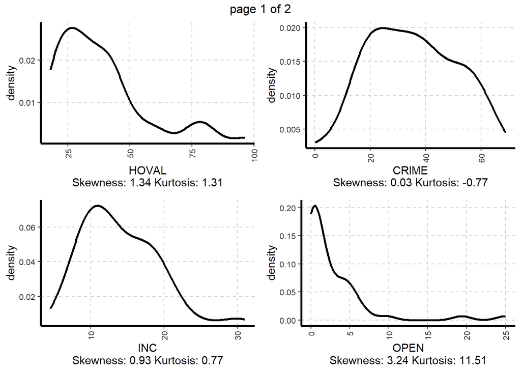

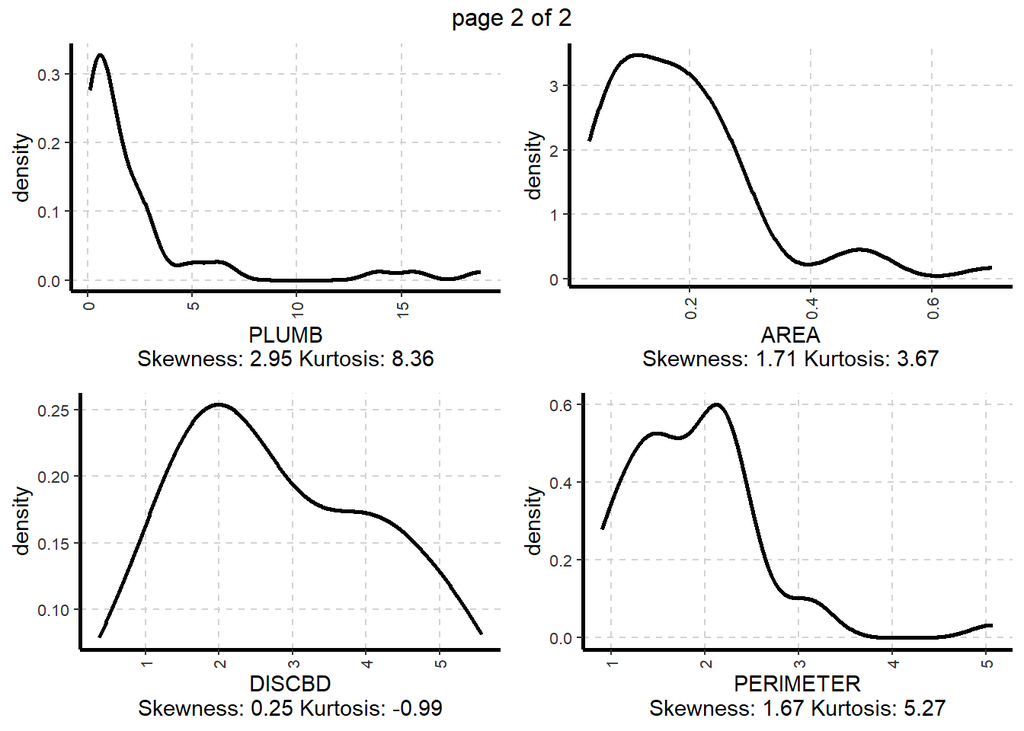

```r
plot1 <- ExpNumViz(analyze,target=NULL,nlim=20,Page=c(2,2),sample=8)
plot1[[1]]
```

Podemos observar la distribución, en este caso las variables de HOVAL, OPEN, PLUMB, AREA y PERIMETER deberán ser transformadas para que tengan una mejor distribución.

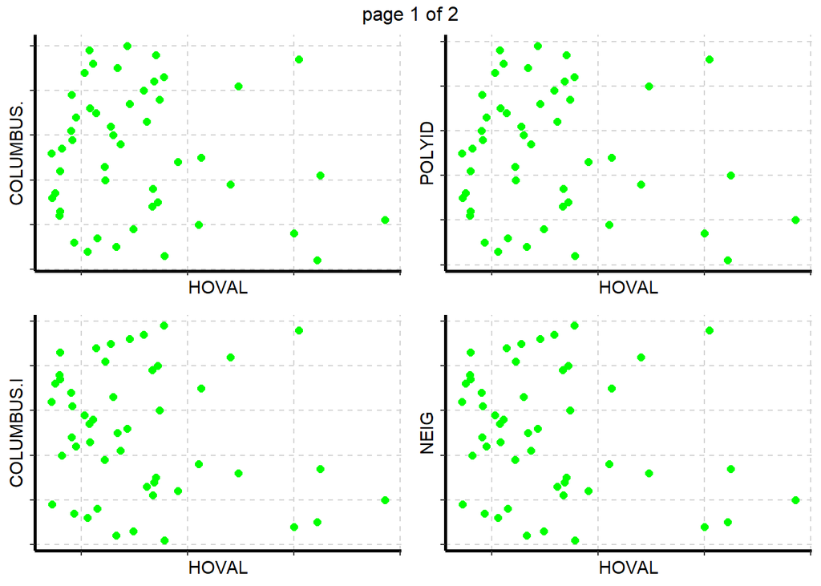

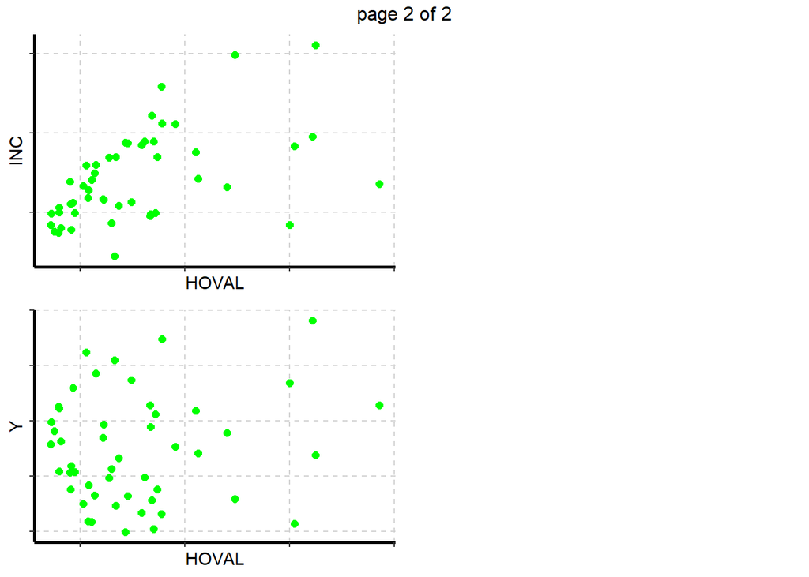

```r
plot3 <- ExpNumViz(columbus,target="HOVAL",nlim=4,scatter=FALSE,fname=NULL,col="green",Page=c(2,2),sample=7)
plot3[[1]]
```

Podemos observar que en en todas las variables existen outliers, además de que en muchos de estos diagramas de dispersión parece no existir una relación clara entre el cambio de una variable con HOVAL.

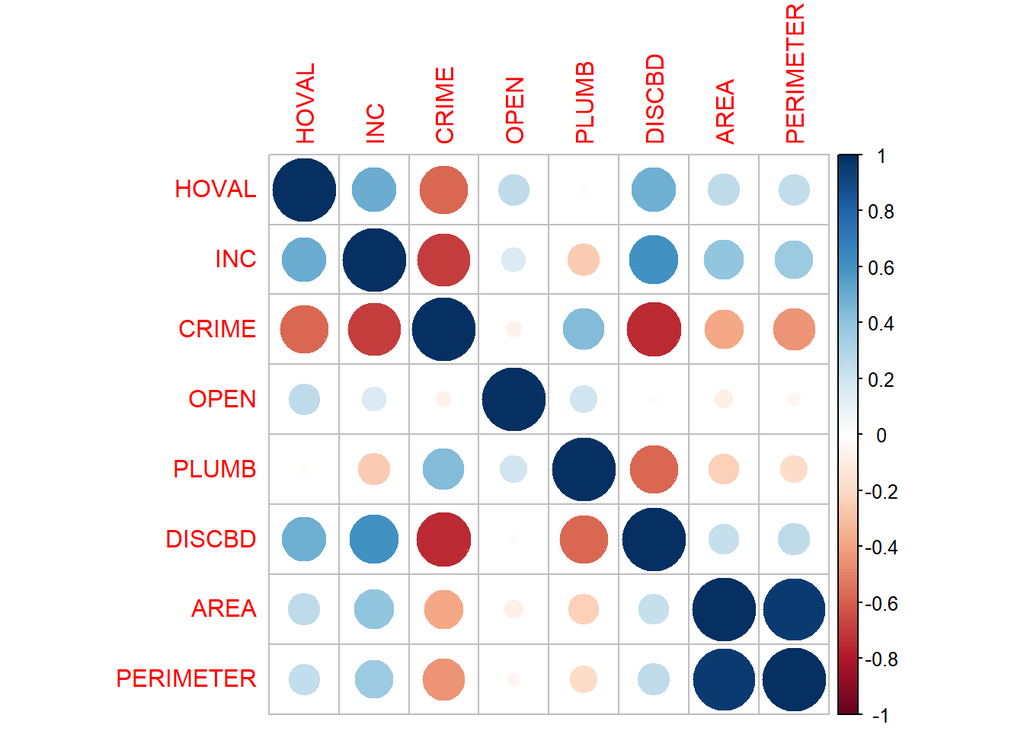

```r
library(corrplot)
CM = cor(analyze)
corrplot(CM)
```

Podemos observar que HOVAL cuenta con las correlaciones más grandes con Income, Crime y distance to CBD. Sorprendentemente, las correlacione con Area y Perimeter no son muy grandes. Claramente existe una relación muy grande entre Area y Perimeter, lo cual pued indicar que son dependientes entre sí. Así mismo vemos que la variable distance to CBD influye mucho en temas como el crimen y el income.

###Transformación de variables

```r
columbus$PLUMB <- log(columbus$PLUMB,10)
columbus$AREA <- log(columbus$AREA,10)
columbus$PERIMETER <- log(columbus$PERIMETER,10)
columbus$HOVAL <- log(columbus$HOVAL,10)
columbus$OPEN <- log(columbus$OPEN,10)
```

```r
columbus_shp$PLUMB <- log(columbus_shp$PLUMB,10)
columbus_shp$AREA <- log(columbus_shp$AREA,10)
columbus_shp$PERIMETER <- log(columbus_shp$PERIMETER,10)
columbus_shp$HOVAL <- log(columbus_shp$HOVAL,10)
columbus_shp$OPEN <- log(columbus_shp$OPEN,10)
```

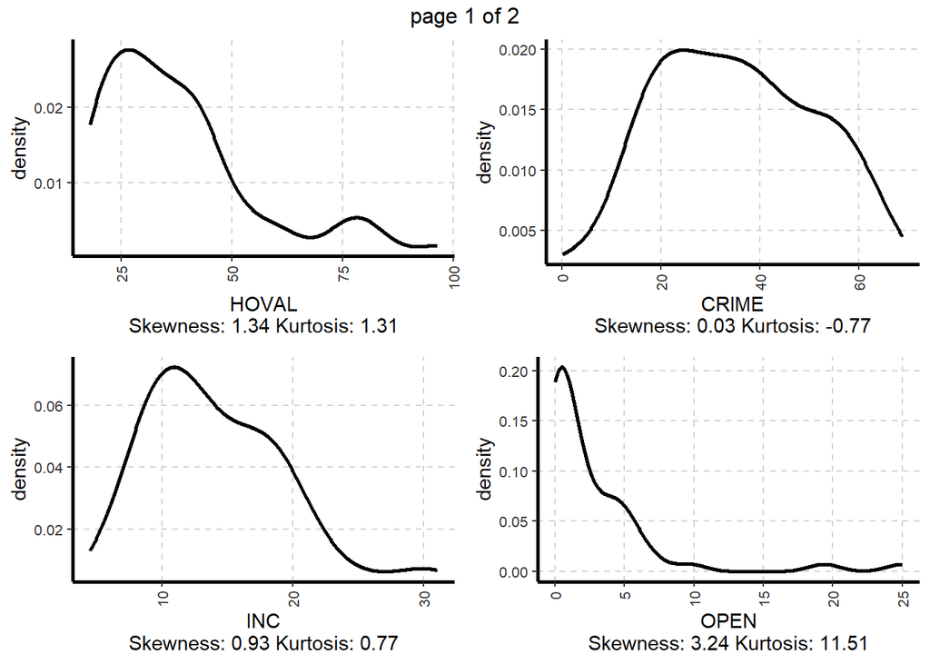

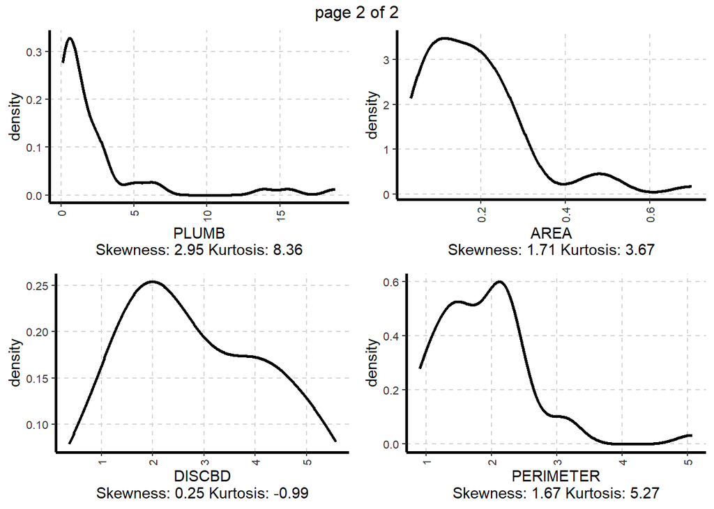

```r
plot1 <- ExpNumViz(analyze,target=NULL,nlim=20,Page=c(2,2),sample=8)
plot1[[1]]
```

##Non Spatial Model

```r
swm_queen <- poly2nb(columbus_shp, queen = TRUE)
```

```r
rswm_queen <- nb2listw(swm_queen, style = "W", zero.policy = TRUE)
```

```r
non_spatial_model = lm(HOVAL ~ AREA + PERIMETER + INC + PLUMB + DISCBD + CRIME, data = columbus_shp)
summary(non_spatial_model)
```

```
##
## Call:
## lm(formula = HOVAL ~ AREA + PERIMETER + INC + PLUMB + DISCBD +
##     CRIME, data = columbus_shp)
##
## Residuals:
##      Min       1Q   Median       3Q      Max
## -0.19531 -0.10486 -0.01533  0.07134  0.39955
##
## Coefficients:
##              Estimate Std. Error t value Pr(>|t|)
## (Intercept)  1.521312   0.384732   3.954 0.000289 ***
## AREA         0.161623   0.263378   0.614 0.542754
## PERIMETER   -0.318060   0.493842  -0.644 0.523043
## INC          0.014324   0.005142   2.786 0.007982 **
## PLUMB        0.256136   0.066394   3.858 0.000387 ***
## DISCBD       0.069997   0.024038   2.912 0.005729 **
## CRIME       -0.004994   0.002030  -2.460 0.018104 *
## ---
## Signif. codes:  0 '***' 0.001 '**' 0.01 '*' 0.05 '.' 0.1 ' ' 1
##
## Residual standard error: 0.1298 on 42 degrees of freedom
## Multiple R-squared:  0.582,  Adjusted R-squared:  0.5223
## F-statistic: 9.745 on 6 and 42 DF,  p-value: 1.015e-06
```

```r
non_spatial_model_2 = lm(HOVAL ~ INC + PLUMB + DISCBD + CRIME, data = columbus_shp)
summary(non_spatial_model_2)
```

```
##
## Call:
## lm(formula = HOVAL ~ INC + PLUMB + DISCBD + CRIME, data = columbus_shp)
##
## Residuals:
##      Min       1Q   Median       3Q      Max
## -0.20251 -0.10939 -0.00472  0.06275  0.41183
##
## Coefficients:
##              Estimate Std. Error t value Pr(>|t|)
## (Intercept)  1.296333   0.149861   8.650 4.79e-11 ***
## INC          0.014715   0.004949   2.974 0.004761 **
## PLUMB        0.243693   0.061758   3.946 0.000282 ***
## DISCBD       0.068356   0.023264   2.938 0.005238 **
## CRIME       -0.004658   0.001854  -2.513 0.015723 *
## ---
## Signif. codes:  0 '***' 0.001 '**' 0.01 '*' 0.05 '.' 0.1 ' ' 1
##
## Residual standard error: 0.1275 on 44 degrees of freedom
## Multiple R-squared:  0.5778, Adjusted R-squared:  0.5395
## F-statistic: 15.06 on 4 and 44 DF,  p-value: 7.9e-08
```

Vemos que la variable con mayor impacto en este caso es la de la plomería, mientras que la menor es la del crimen. Es importante tomar en cuenta que algunas de nuestras variables se encuentran transformadas con log. El modelo cuent con un valor ajustado de R2 de 0.54.

```r
AIC(non_spatial_model_2)
```

```
## [1] -56.09972
```

Podemos observar que cuenta con un AIC de -56, esto se usará para comparar con otros modelos.

##Multicolinearidad

```r
VIF(non_spatial_model_2)
```

```
##      INC    PLUMB   DISCBD    CRIME
## 2.353790 3.359497 3.332311 2.843018
```

Podemos observar que, aunque los valores de PLUMB y DISCBD son algo grandes, podemos omitir una regularización al no ser muy grandes.

###Diagnóstico para dependencia espacial

```r
lm.LMtests(non_spatial_model_2,rswm_queen,test=c("RLMlag"))
```

```
##
##  Lagrange multiplier diagnostics for spatial dependence
##
## data:
## model: lm(formula = HOVAL ~ INC + PLUMB + DISCBD + CRIME, data =
## columbus_shp)
## weights: rswm_queen
##
## RLMlag = 0.44811, df = 1, p-value = 0.5032
```

Debido al p value de 0.5 podemos concluir que no debemos incluir el lag de la variable dependiente en nuestro modelo.

###Diagnóstico del error de dependencia global espacial

```r
lm.LMtests(non_spatial_model_2,rswm_queen,test=c("RLMerr"))
```

```
##
##  Lagrange multiplier diagnostics for spatial dependence
##
## data:
## model: lm(formula = HOVAL ~ INC + PLUMB + DISCBD + CRIME, data =
## columbus_shp)
## weights: rswm_queen
##
## RLMerr = 0.84654, df = 1, p-value = 0.3575
```

Debido al p-value de 0.37, se nos sugiere no incluir el lag del error en nuestro modelo.

Tomando en cuenta que no haremos ningún cambio podemos continuar con los modelos espaciales.

##ESDA

###Identificar autocorrelación espacial global de 3-5 variables de interés

```r
moran.test(columbus_shp$HOVAL, listw = rswm_queen, zero.policy = TRUE, na.action = na.omit)
```

```
##
##  Moran I test under randomisation
##
## data:  columbus_shp$HOVAL
## weights: rswm_queen
##
## Moran I statistic standard deviate = 2.9453, p-value = 0.001613
## alternative hypothesis: greater
## sample estimates:
## Moran I statistic       Expectation          Variance
##       0.252777699      -0.020833333       0.008629742
```

La autocorrelación espacial de HOVAL es un poco baja al ser de 0.26 y es positiva. Podemos ver que el p-value es de 0.001, por lo que podemos ver que existe una autocorrelación espacial global en HOVAL.

```r
moran.test(columbus_shp$INC, listw = rswm_queen, zero.policy = TRUE, na.action = na.omit)
```

```
##
##  Moran I test under randomisation
##
## data:  columbus_shp$INC
## weights: rswm_queen
##
## Moran I statistic standard deviate = 4.7645, p-value = 9.467e-07
## alternative hypothesis: greater
## sample estimates:
## Moran I statistic       Expectation          Variance
##       0.415628778      -0.020833333       0.008391926
```

La autocorrelación espacial de Income es 0.415 y es positiva. Podemos ver que el p-value es muy bajo, por lo que podemos ver que existe una autocorrelación espacial global en INC.

```r
moran.test(columbus_shp$PLUMB, listw = rswm_queen, zero.policy = TRUE, na.action = na.omit)
```

```
##
##  Moran I test under randomisation
##
## data:  columbus_shp$PLUMB
## weights: rswm_queen
##
## Moran I statistic standard deviate = 7.5613, p-value = 1.996e-14
## alternative hypothesis: greater
## sample estimates:
## Moran I statistic       Expectation          Variance
##       0.681818585      -0.020833333       0.008635588
```

```r
moran.test(columbus_shp$CRIME, listw = rswm_queen, zero.policy = TRUE, na.action = na.omit)
```

```
##
##  Moran I test under randomisation
##
## data:  columbus_shp$CRIME
## weights: rswm_queen
##
## Moran I statistic standard deviate = 5.5894, p-value = 1.139e-08
## alternative hypothesis: greater
## sample estimates:
## Moran I statistic       Expectation          Variance
##       0.500188557      -0.020833333       0.008689289
```

La autocorrelación espacial de CRIME es alta-media al ser de 0.5 y es positiva. Podemos ver que el p-value es mínimo, por lo que podemos ver que existe una autocorrelación espacial global en CRIME. Esta será una de las variables con mayor autocorrelación global debido a los patrones de crimen por zonas.

```r
moran.test(columbus_shp$DISCBD, listw = rswm_queen, zero.policy = TRUE, na.action = na.omit)
```

```
##
##  Moran I test under randomisation
##
## data:  columbus_shp$DISCBD
## weights: rswm_queen
##
## Moran I statistic standard deviate = 8.7904, p-value < 2.2e-16
## alternative hypothesis: greater
## sample estimates:
## Moran I statistic       Expectation          Variance
##       0.800562617      -0.020833333       0.008731396
```

En este caso podemos observar que la autocorrelación global de distancia a centros de negocios como downtown es muy alta, con 0.8. Esto tiene sentido al ser una variable que toma en cuenta la distancia a unos puntos en específico.

###Autocorrelación espacial local

```r
columbus_shp_alt = st_read(system.file("etc/shapes/columbus.shp", package="spdep"))
queen_w_2<-queen_weights(columbus_shp_alt) ### built it for detecting clusters across space
```

```r
lisa_1<-local_moran(queen_w_2, columbus_shp_alt["HOVAL"])
columbus_shp_alt$p_vals <-lisa_1$p_vals
```

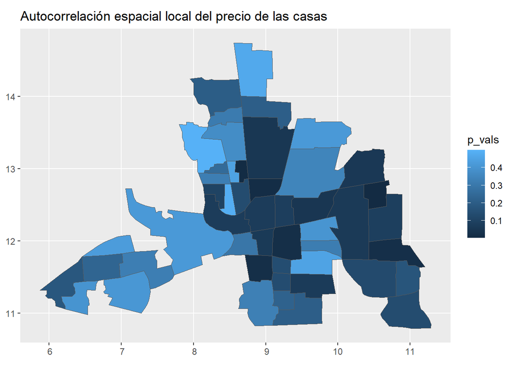

```r
ggplot(data=columbus_shp_alt) +
  geom_sf(aes(fill=p_vals)) +
  ggtitle(label = "Autocorrelación espacial local del precio de las casas")
```

En este caso vemos que los lugares donde los p values son menores se encuentran al este, el centro y el sur de la ciudad. Esto nos indica los lugares donde el valor de los hogares se encuentran localmente especialmente relacionados, significando que cuentan con valores que se pueden agrupar en estas zonas.

```r
lisa_2<-local_moran(queen_w_2, columbus_shp_alt["CRIME"])
columbus_shp_alt$p_vals <-lisa_2$p_vals
```

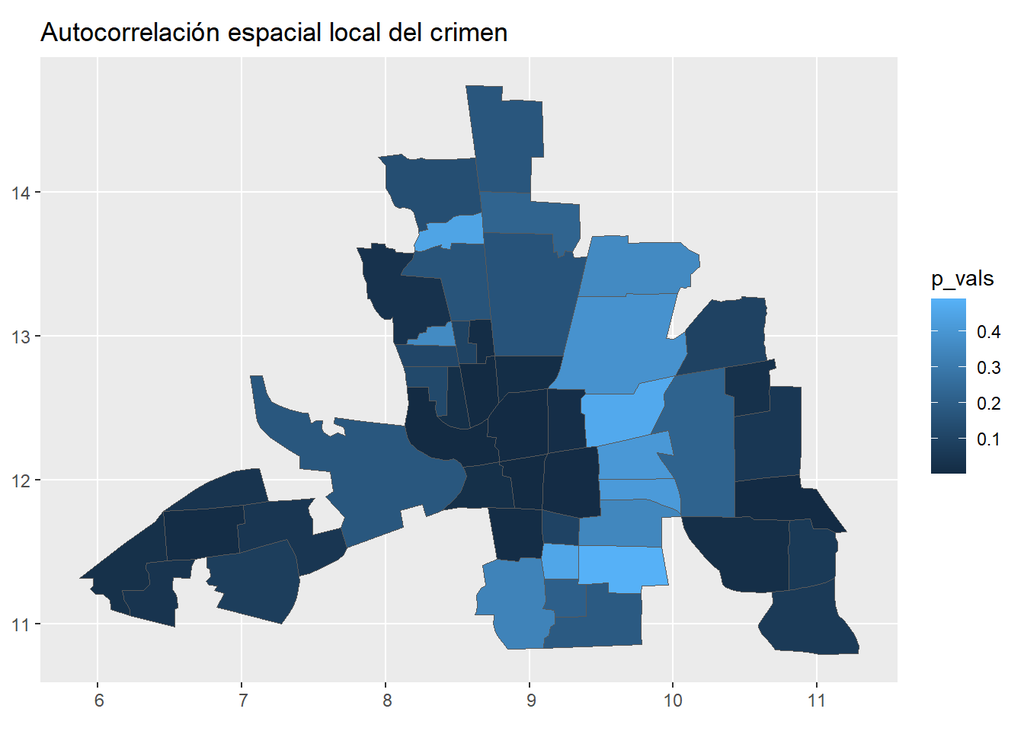

```r
ggplot(data=columbus_shp_alt) +
  geom_sf(aes(fill=p_vals)) +
  ggtitle(label = "Autocorrelación espacial local del crimen")
```

En este caso observamos que al centro-oeste, al suroeste y al este es donde encontramos la mayor significancia debido a p-values pequeños. En este caso coinciden los del centro y el este con unos de house value, por lo que pueden ser grupos que comparten características de estas dos variables.

```r
lisa_3 <-local_moran(queen_w_2, columbus_shp_alt["INC"])
columbus_shp_alt$p_vals <-lisa_3$p_vals
```

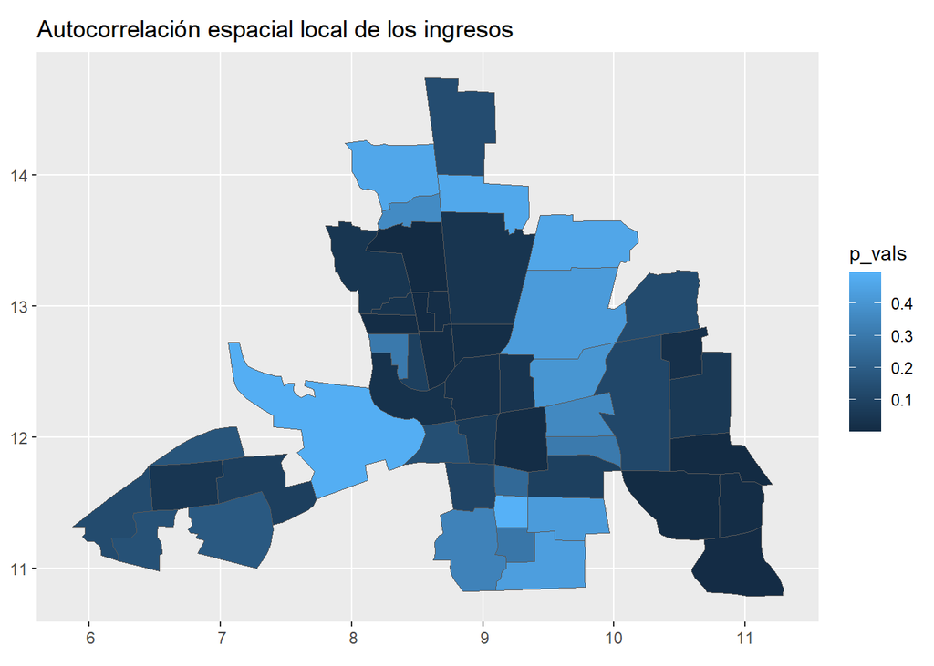

```r
ggplot(data=columbus_shp_alt) +
  geom_sf(aes(fill=p_vals)) +
  ggtitle(label = "Autocorrelación espacial local de los ingresos")
```

En este caso observamos casi los mismos clusters de la gráfica anterior. Esto tiene sentido, ya que al contar con mayores ingresos las personas van a desear vivir en zonas más seguras. Aemás, parece estar relacionado con el valor de la casa.

```r
lisa_4 <-local_moran(queen_w_2, columbus_shp_alt["DISCBD"])
columbus_shp_alt$p_vals <-lisa_4$p_vals
```

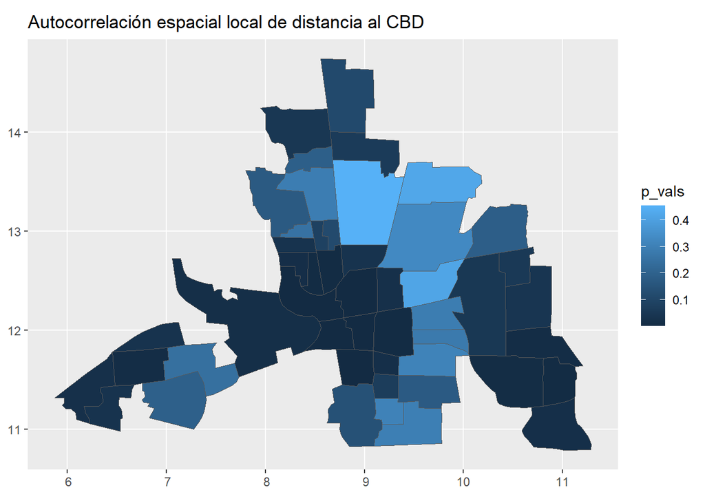

```r
ggplot(data=columbus_shp_alt) +
  geom_sf(aes(fill=p_vals)) +
  ggtitle(label = "Autocorrelación espacial local de distancia al CBD")
```

En este caso observamos grupos similares al anterior, aunque la mayoría parece contar con un pvalue muy pequeño, indicando una autocorrelación local muy grande. Así mismo, paece indicar que algunos de estos grupos están también relacionados con el crimen.

###Spatial Durbin Model

```r
spatial_durbin <- lagsarlm(HOVAL ~ AREA + PERIMETER + INC + PLUMB + DISCBD + CRIME, data = columbus_shp, rswm_queen, type="mixed")
summary(spatial_durbin)
```

```
##
## Call:lagsarlm(formula = HOVAL ~ AREA + PERIMETER + INC + PLUMB + DISCBD +
##     CRIME, data = columbus_shp, listw = rswm_queen, type = "mixed")
##
## Residuals:
##        Min         1Q     Median         3Q        Max
## -0.1698065 -0.0963989 -0.0077632  0.0640366  0.3215450
##
## Type: mixed
## Coefficients: (asymptotic standard errors)
##                 Estimate Std. Error z value  Pr(>|z|)
## (Intercept)    0.4813953  1.0130910  0.4752 0.6346624
## AREA           0.2686223  0.2621509  1.0247 0.3055115
## PERIMETER     -0.6323475  0.5044505 -1.2535 0.2100102
## INC            0.0156610  0.0044819  3.4943 0.0004754
## PLUMB          0.2098930  0.0620048  3.3851 0.0007115
## DISCBD         0.2052662  0.0545338  3.7640 0.0001672
## CRIME         -0.0050987  0.0017431 -2.9250 0.0034445
## lag.AREA      -0.6359356  0.6666935 -0.9539 0.3401520
## lag.PERIMETER  1.2027498  1.2966569  0.9276 0.3536267
## lag.INC        0.0057426  0.0089287  0.6432 0.5201238
## lag.PLUMB     -0.0113712  0.1775599 -0.0640 0.9489374
## lag.DISCBD    -0.1640100  0.0859070 -1.9092 0.0562418
## lag.CRIME      0.0051345  0.0048079  1.0679 0.2855476
##
## Rho: 0.11336, LR test value: 0.29459, p-value: 0.58729
## Asymptotic standard error: 0.19434
##     z-value: 0.58332, p-value: 0.55968
## Wald statistic: 0.34026, p-value: 0.55968
##
## Log likelihood: 40.48733 for mixed model
## ML residual variance (sigma squared): 0.011184, (sigma: 0.10575)
## Number of observations: 49
## Number of parameters estimated: 15
## AIC: -50.975, (AIC for lm: -52.68)
## LM test for residual autocorrelation
## test value: 0.10604, p-value: 0.7447
```

En ese caso podemos observar que las variables de AREA y PERIMETER no son significativas, por lo que volveremos a hacer el modelo sin estas.

```r
spatial_durbin_2 <- lagsarlm(HOVAL ~ INC + PLUMB + DISCBD + CRIME, data = columbus_shp, rswm_queen,  type="mixed")
summary(spatial_durbin_2)
```

```
##
## Call:
## lagsarlm(formula = HOVAL ~ INC + PLUMB + DISCBD + CRIME, data = columbus_shp,
##     listw = rswm_queen, type = "mixed")
##
## Residuals:
##       Min        1Q    Median        3Q       Max
## -0.198548 -0.090794 -0.010434  0.057567  0.332634
##
## Type: mixed
## Coefficients: (asymptotic standard errors)
##               Estimate Std. Error z value  Pr(>|z|)
## (Intercept)  0.9577644  0.3642958  2.6291 0.0085615
## INC          0.0162415  0.0043689  3.7175 0.0002012
## PLUMB        0.2118240  0.0634456  3.3387 0.0008418
## DISCBD       0.1855228  0.0503090  3.6877 0.0002263
## CRIME       -0.0044506  0.0015959 -2.7887 0.0052918
## lag.INC      0.0016408  0.0084650  0.1938 0.8463082
## lag.PLUMB    0.0400071  0.1216819  0.3288 0.7423189
## lag.DISCBD  -0.1239565  0.0701394 -1.7673 0.0771802
## lag.CRIME    0.0036753  0.0039132  0.9392 0.3476232
##
## Rho: 0.10669, LR test value: 0.26887, p-value: 0.60409
## Asymptotic standard error: 0.19406
##     z-value: 0.54979, p-value: 0.58246
## Wald statistic: 0.30227, p-value: 0.58246
##
## Log likelihood: 39.1963 for mixed model
## ML residual variance (sigma squared): 0.011793, (sigma: 0.1086)
## Number of observations: 49
## Number of parameters estimated: 11
## AIC: -56.393, (AIC for lm: -58.124)
## LM test for residual autocorrelation
## test value: 0.26727, p-value: 0.60517
```

```r
AIC(spatial_durbin_2)
```

```
## [1] -56.39261
```

```r
fitted_sp <- SpatialPolygonsDataFrame(columbus_shp, data = data.frame(spatial_durbin_2$fitted.values))
```

```r
spplot(fitted_sp, "spatial_durbin_2.fitted.values", main = "Fitted Values")
```

[output not shown]

### 0.1.1 Estimar Geographic Weighted Regression (GWR) (Modelo Local)

```r
bw1 <- bw.gwr(HOVAL ~ AREA + PERIMETER + INC + PLUMB + DISCBD + CRIME,
             approach = "AIC", adaptive = T, data=columbus_shp)
```

```
## Adaptive bandwidth (number of nearest neighbours): 37 AICc value: -34.79597
## Adaptive bandwidth (number of nearest neighbours): 31 AICc value: -20.84695
## Adaptive bandwidth (number of nearest neighbours): 42 AICc value: -42.01465
## Adaptive bandwidth (number of nearest neighbours): 44 AICc value: -43.32915
## Adaptive bandwidth (number of nearest neighbours): 46 AICc value: -44.12977
## Adaptive bandwidth (number of nearest neighbours): 47 AICc value: -44.41314
## Adaptive bandwidth (number of nearest neighbours): 48 AICc value: -45.11487
## Adaptive bandwidth (number of nearest neighbours): 48 AICc value: -45.11487
```

```r
m.gwr <- gwr.basic(HOVAL ~ AREA + PERIMETER + INC + PLUMB + DISCBD + CRIME, adaptive = T, data = columbus_shp, bw = bw1)
```

```r
m.gwr
```

```
##    *                       Package   GWmodel                             *
##    Program starts at: 2023-05-13 00:46:41
##    Call:
##    gwr.basic(formula = HOVAL ~ AREA + PERIMETER + INC + PLUMB +
##     DISCBD + CRIME, data = columbus_shp, bw = bw1, adaptive = T)
##
##    Dependent (y) variable:  HOVAL
##    Independent variables:  AREA PERIMETER INC PLUMB DISCBD CRIME
##    Number of data points: 49
##    *                    Results of Global Regression                     *
##
##    Call:
##     lm(formula = formula, data = data)
##
##    Residuals:
##      Min       1Q   Median       3Q      Max
## -0.19531 -0.10486 -0.01533  0.07134  0.39955
##
##    Coefficients:
##                 Estimate Std. Error t value Pr(>|t|)
##    (Intercept)  1.521312   0.384732   3.954 0.000289 ***
##    AREA         0.161623   0.263378   0.614 0.542754
##    PERIMETER   -0.318060   0.493842  -0.644 0.523043
##    INC          0.014324   0.005142   2.786 0.007982 **
##    PLUMB        0.256136   0.066394   3.858 0.000387 ***
##    DISCBD       0.069997   0.024038   2.912 0.005729 **
##    CRIME       -0.004994   0.002030  -2.460 0.018104 *
##
##    ---Significance stars
##    Signif. codes:  0 '***' 0.001 '**' 0.01 '*' 0.05 '.' 0.1 ' ' 1
##    Residual standard error: 0.1298 on 42 degrees of freedom
##    Multiple R-squared: 0.582
##    Adjusted R-squared: 0.5223
##    F-statistic: 9.745 on 6 and 42 DF,  p-value: 1.015e-06
##    ***Extra Diagnostic information
##    Residual sum of squares: 0.7077406
##    Sigma(hat): 0.1227123
##    AIC:  -52.58143
##    AICc:  -48.98143
##    BIC:  -55.3123
```

[output cut: 14 more lines]

```
##    PLUMB      0.1691683  0.2163079  0.2438007  0.2747209  0.3326
##    DISCBD     0.0414938  0.0536252  0.0680754  0.0800449  0.1032
##    CRIME     -0.0064751 -0.0060020 -0.0051479 -0.0039497 -0.0024
##    ************************Diagnostic information*************************
##    Number of data points: 49
##    Effective number of parameters (2trace(S) - trace(S'S)): 13.56213
##    Effective degrees of freedom (n-2trace(S) + trace(S'S)): 35.43787
##    AICc (GWR book, Fotheringham, et al. 2002, p. 61, eq 2.33): -45.11487
##    AIC (GWR book, Fotheringham, et al. 2002,GWR p. 96, eq. 4.22): -67.69725
##    BIC (GWR book, Fotheringham, et al. 2002,GWR p. 61, eq. 2.34): -83.89344
##    Residual sum of squares: 0.5717025
##    R-square value:  0.6623218
##    Adjusted R-square value:  0.5293392
##
##    Program stops at: 2023-05-13 00:46:41
```

Al igual que en el resto de los modelos, volveremos a calcularlo sin AREA y Perimeter debido a que no son significativas.

```r
m.gwr_2 <- gwr.basic(HOVAL ~ INC + PLUMB + DISCBD + CRIME, adaptive = T, data = columbus_shp, bw = bw1)
```

```r
m.gwr_2
```

```
##    *                       Package   GWmodel                             *
##    Program starts at: 2023-05-13 00:46:41
##    Call:
##    gwr.basic(formula = HOVAL ~ INC + PLUMB + DISCBD + CRIME, data = columbus_shp,
##     bw = bw1, adaptive = T)
##
##    Dependent (y) variable:  HOVAL
##    Independent variables:  INC PLUMB DISCBD CRIME
##    Number of data points: 49
##    *                    Results of Global Regression                     *
##
##    Call:
##     lm(formula = formula, data = data)
##
##    Residuals:
##      Min       1Q   Median       3Q      Max
## -0.20251 -0.10939 -0.00472  0.06275  0.41183
##
##    Coefficients:
##                 Estimate Std. Error t value Pr(>|t|)
##    (Intercept)  1.296333   0.149861   8.650 4.79e-11 ***
##    INC          0.014715   0.004949   2.974 0.004761 **
##    PLUMB        0.243693   0.061758   3.946 0.000282 ***
##    DISCBD       0.068356   0.023264   2.938 0.005238 **
##    CRIME       -0.004658   0.001854  -2.513 0.015723 *
##
##    ---Significance stars
##    Signif. codes:  0 '***' 0.001 '**' 0.01 '*' 0.05 '.' 0.1 ' ' 1
##    Residual standard error: 0.1275 on 44 degrees of freedom
##    Multiple R-squared: 0.5778
##    Adjusted R-squared: 0.5395
##    F-statistic: 15.06 on 4 and 44 DF,  p-value: 7.9e-08
##    ***Extra Diagnostic information
##    Residual sum of squares: 0.7147325
##    Sigma(hat): 0.123317
##    AIC:  -56.09972
##    AICc:  -54.09972
##    BIC:  -70.39787
##    *          Results of Geographically Weighted Regression              *
##
```

[output cut: 10 more lines]

```
##    PLUMB      0.1714312  0.2194461  0.2490197  0.2732964  0.3200
##    DISCBD     0.0444083  0.0589491  0.0681858  0.0815453  0.1038
##    CRIME     -0.0058109 -0.0052957 -0.0046892 -0.0038997 -0.0023
##    ************************Diagnostic information*************************
##    Number of data points: 49
##    Effective number of parameters (2trace(S) - trace(S'S)): 10.33683
##    Effective degrees of freedom (n-2trace(S) + trace(S'S)): 38.66317
##    AICc (GWR book, Fotheringham, et al. 2002, p. 61, eq 2.33): -52.05653
##    AIC (GWR book, Fotheringham, et al. 2002,GWR p. 96, eq. 4.22): -67.88078
##    BIC (GWR book, Fotheringham, et al. 2002,GWR p. 61, eq. 2.34): -92.11127
##    Residual sum of squares: 0.6027926
##    R-square value:  0.6439583
##    Adjusted R-square value:  0.546241
##
##    Program stops at: 2023-05-13 00:46:41
```

En este caso vemos que las variables con mayor impacto son plomería y la distancia centro. Así mismo, la única variable negativa es crimen, lo que significa que si disminuye el crimen aumentará el valor.

```r
gwr_sf = st_as_sf(m.gwr_2$SDF)
```

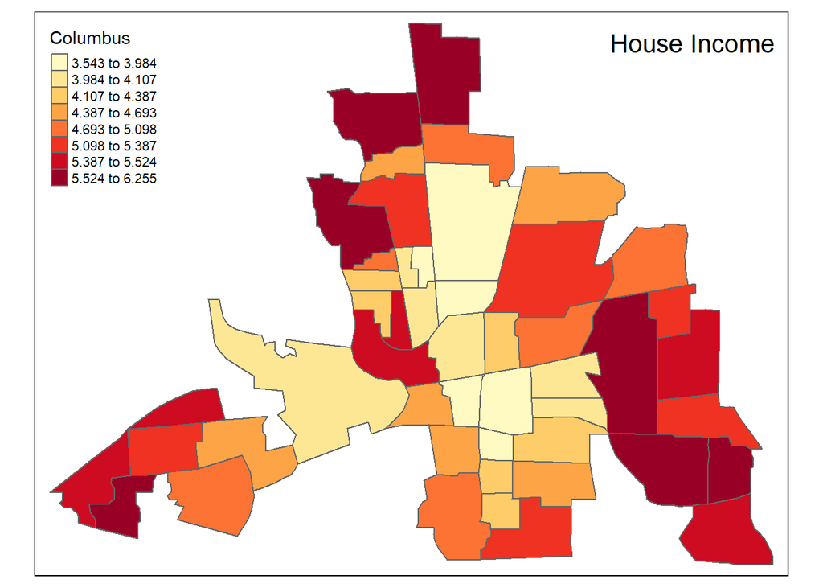

```r
gwr_sf$y_predicted <- exp(gwr_sf$yhat)
#mapview(gwr_sf, zcol="y_predicted", col.regions=brewer.pal(5, "Oranges"))
tm_shape(gwr_sf) +
  tm_polygons(col = "y_predicted", palette="YlOrRd", style="quantile", n=8, title="Columbus") +
   tm_layout(title= 'House Income',  title.position = c('right', 'top'))
```

En este caso observamos algo similar a la predicción del modelo anterior, donde las propiedades con mayor valor se encuentran al este, la costa oeste y el norte. Por el contrario el centro y sur-centro parecen tener los valores más pequeños.

### 0.1.2 Autocorrelación Espacial de los residuales estimados

```r
moran.test(exp(spatial_durbin_2$residuals), rswm_queen)
```

```
##
##  Moran I test under randomisation
##
## data:  exp(spatial_durbin_2$residuals)
## weights: rswm_queen
##
## Moran I statistic standard deviate = 0.090264, p-value = 0.464
## alternative hypothesis: greater
## sample estimates:
## Moran I statistic       Expectation          Variance
##      -0.012607272      -0.020833333       0.008305335
```

```r
moran.test(exp(gwr_sf$residual), rswm_queen)
```

```
##
##  Moran I test under randomisation
##
## data:  exp(gwr_sf$residual)
## weights: rswm_queen
##
## Moran I statistic standard deviate = 0.31026, p-value = 0.3782
## alternative hypothesis: greater
## sample estimates:
## Moran I statistic       Expectation          Variance
##       0.006690518      -0.020833333       0.007869721
```

En ambos casos podemos observar que contamos con valores del estadístico de Moran muy bajos (-0.012 y 0.006), además de contar con p-values altos. Esto nos indica que no existe una autocorrelación espacial de nuestros residuales y que al parecer sí podemos predecir el valor de las casas con nuestro modelo.

###Selección de modelo

```r
AIC(spatial_durbin_2)
```

```
## [1] -56.39261
```

###Predicción de House Value

```r
fitted_sp <- SpatialPolygonsDataFrame(columbus_shp, data = data.frame(spatial_durbin_2$fitted.values))
```

```r
spplot(fitted_sp, "spatial_durbin_2.fitted.values", main = "Fitted Values")
```

[output not shown]

###Clústers

*Crimen*

```r
map_cluster1 <- columbus_shp_alt
```

```r
lisa_ppp <-local_moran(queen_w_2, columbus_shp_alt["CRIME"])
map_cluster1$cluster_ppp<-as.factor(lisa_ppp$GetClusterIndicators())
levels(map_cluster1$cluster_ppp)<-lisa_ppp$GetLabels()
```

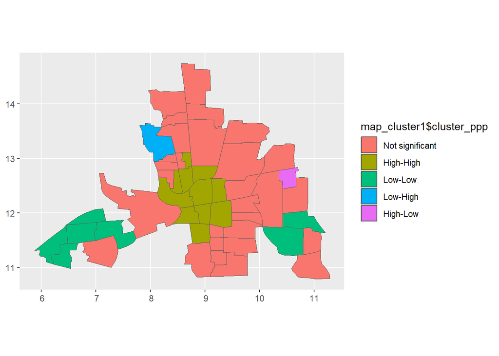

```r
  ggplot(data=map_cluster1) +
  geom_sf(aes(fill=map_cluster1$cluster_ppp))
```

En este caso podemos observar que existen dos clusters principales. El primero es en el centro con autocorrelación espacial de crimen HIGH-HIGH y el segundo en el oeste con LOW-LOW. Podemos ver que en el caso del oeste este será un lugar donde los precios de las viviendas serán muy altos, mientras que en la mayoría del centro bajos.

*PLUMB*

```r
map_cluster2 <- columbus_shp_alt
```

```r
lisa_ppp <-local_moran(queen_w_2, columbus_shp_alt["PLUMB"])
map_cluster2$cluster_ppp<-as.factor(lisa_ppp$GetClusterIndicators())
levels(map_cluster2$cluster_ppp)<-lisa_ppp$GetLabels()
```

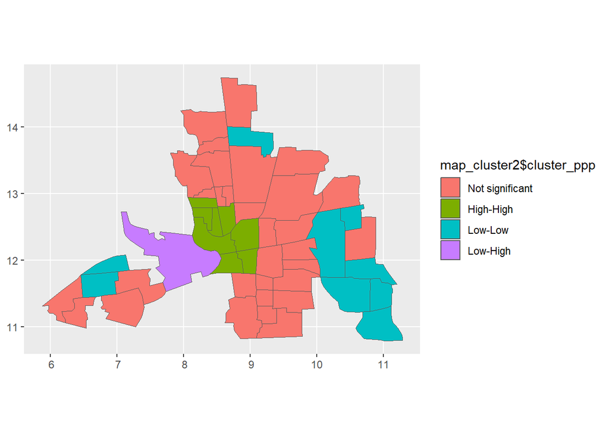

```r
  ggplot(data=map_cluster2) +
  geom_sf(aes(fill=map_cluster2$cluster_ppp))
```

*Income*

```r
map_cluster3 <- columbus_shp_alt
```

```r
lisa_ppp <-local_moran(queen_w_2, columbus_shp_alt["INC"])
map_cluster3$cluster_ppp<-as.factor(lisa_ppp$GetClusterIndicators())
levels(map_cluster3$cluster_ppp)<-lisa_ppp$GetLabels()
```

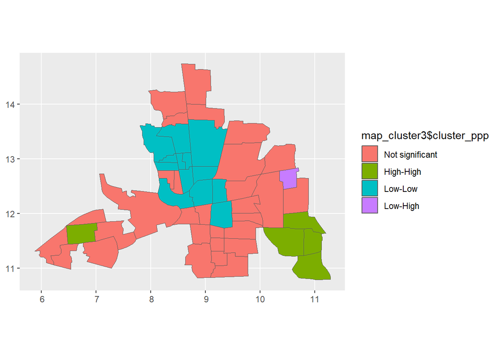

```r
  ggplot(data=map_cluster3) +
  geom_sf(aes(fill=map_cluster3$cluster_ppp))
```

*Distancia a centros de negocios*

```r
map_cluster4 <- columbus_shp_alt
```

```r
lisa_ppp <-local_moran(queen_w_2, columbus_shp_alt["DISCBD"])
map_cluster4$cluster_ppp<-as.factor(lisa_ppp$GetClusterIndicators())
levels(map_cluster4$cluster_ppp)<-lisa_ppp$GetLabels()
```

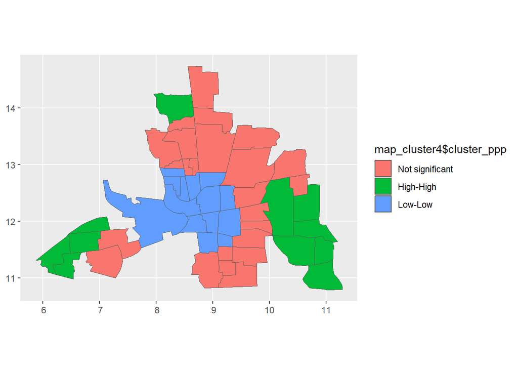

```r
  ggplot(data=map_cluster4) +
  geom_sf(aes(fill=map_cluster4$cluster_ppp))
```

###Predicción

```r
fitted_sp <- SpatialPolygonsDataFrame(columbus_shp, data = data.frame(spatial_durbin_2$fitted.values))
```

```r
spplot(fitted_sp, "spatial_durbin_2.fitted.values", main = "Fitted Values")
```

[output not shown]

##Hallazgos